# Solutions-Functions-Packages slides

Student: Fernanda da Silva

**Exercise 1:** Write a function that computes the level of output generated by a constant returns to scale Cobb-Douglas production function, i.e., such that it computes $A\cdot K^\alpha \cdot L^{1-\alpha}$.

```python
def CobbDouglas(K=1, L=1, A=1, alpha=0.3):
    '''
    This function computes the level of output of a Cobb-Douglas production function.
    Given values of K, L, A, and alpha it returns $A\cdot K^\alpha \cdot L^{1-\alpha}$.
    Parameters:
    -----------
    K: float, integer or any other number, default=1
    L: float, integer or any other number, default=1
    A: float, integer or any other number, default=1
    alpha: float between (0,1), default=0.3

    Returns:
    --------
    out = A * K**alpha * L**(1-alpha)

    Example:
    >>> out = CobbDouglas(4, 9, 2, 1/2)
    >>> out
        12
    '''

    output = A * (K ** alpha) * (L ** (1 - alpha))
    return output

# Example usage:
A = 1  # Total factor productivity
K = 1  # Capital input
L = 1  # Labor input
alpha = 0.3  # Capital's share in output

output_level = CobbDouglas(A, K, L, alpha)
print("Output level:", output_level)
```

```
Output level: 1.0
```

**Exercise 2:** Use the function you created and plot the production function as a function of $K$ for given values of $A$ and $L$. **Hint:** Use the `np.linspace(0, 5, 100)` function to create an array of values of $K$ with 100 point between 0 and 5.

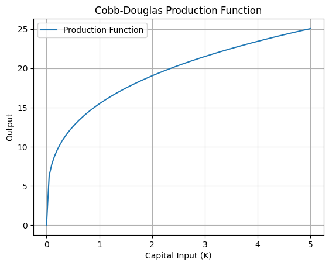

```python
import numpy as np
import matplotlib.pyplot as plt

def CobbDouglas(A, K, L, alpha):
    '''
    This function computes the level of output of a Cobb-Douglas production function.
    Given values of K, L, A, and alpha it returns $A\cdot K^\alpha \cdot L^{1-\alpha}$.
    Parameters:
    -----------
    K: float, integer or any other number, default=1
    L: float, integer or any other number, default=1
    A: float, integer or any other number, default=1
    alpha: float between (0,1), default=0.3

    Returns:
    --------
    out = A * K**alpha * L**(1-alpha)

    Example:
    >>> out = CobbDouglas(4, 9, 2, 1/2)
    >>> out
        12
    '''
    output = A * (K ** alpha) * (L ** (1 - alpha))
    return output

# Given values
A = 1.0  # Total factor productivity
L = 50.0  # Labor input
alpha = 0.3  # Capital's share in output

# Generate an array of values for K
K_values = np.linspace(0, 5, 100)

# Compute the output for each value of K
output_values = CobbDouglas(A, K_values, L, alpha)

# Plot the production function
plt.plot(K_values, output_values, label='Production Function')
plt.xlabel('Capital Input (K)')
plt.ylabel('Output')
plt.title('Cobb-Douglas Production Function')
plt.grid(True)
plt.legend()
plt.show()
```

**Exercise 3:** Show with a plot the effect of increasing $A$ from 1 to 2, 4, or 5.

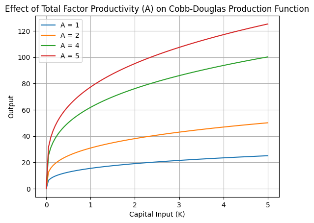

```python
def CobbDouglas(A, K, L, alpha):
    '''
    This function computes the level of output of a Cobb-Douglas production function.
    Given values of K, L, A, and alpha it returns $A\cdot K^\alpha \cdot L^{1-\alpha}$.
    Parameters:
    -----------
    K: float, integer or any other number, default=1
    L: float, integer or any other number, default=1
    A: float, integer or any other number, default=1
    alpha: float between (0,1), default=0.3

    Returns:
    --------
    out = A * K**alpha * L**(1-alpha)

    Example:
    >>> out = CobbDouglas(4, 9, 2, 1/2)
    >>> out
        12
    '''
    output = A * (K ** alpha) * (L ** (1 - alpha))
    return output

# Given values
L = 50.0  # Labor input
alpha = 0.3  # Capital's share in output

# Generate an array of values for K
K_values = np.linspace(0, 5, 100)

# Values of A to analyze
A_values = [1, 2, 4, 5]

# Plot the production function for each value of A
for A in A_values:
    output_values = CobbDouglas(A, K_values, L, alpha)
    plt.plot(K_values, output_values, label=f'A = {A}')

plt.xlabel('Capital Input (K)')
plt.ylabel('Output')
plt.title('Effect of Total Factor Productivity (A) on Cobb-Douglas Production Function')
plt.grid(True)
plt.legend()
plt.show()
```

**Exercise 4:** Show with a plot the effect of increasing $L$ from 1 to 2, 4, 5.

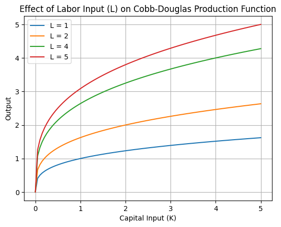

```python
def CobbDouglas(A, K, L, alpha):
    '''
    This function computes the level of output of a Cobb-Douglas production function.
    Given values of K, L, A, and alpha it returns $A\cdot K^\alpha \cdot L^{1-\alpha}$.
    Parameters:
    -----------
    K: float, integer or any other number, default=1
    L: float, integer or any other number, default=1
    A: float, integer or any other number, default=1
    alpha: float between (0,1), default=0.3

    Returns:
    --------
    out = A * K**alpha * L**(1-alpha)

    Example:
    >>> out = CobbDouglas(4, 9, 2, 1/2)
    >>> out
        12
    '''
    output = A * (K ** alpha) * (L ** (1 - alpha))
    return output

    # Given values
A = 1.0  # Total factor productivity
alpha = 0.3  # Capital's share in output

# Generate an array of values for K
K_values = np.linspace(0, 5, 100)

# Values of L to analyze
L_values = [1, 2, 4, 5]

# Plot the production function for each value of L
for L in L_values:
    output_values = CobbDouglas(A, K_values, L, alpha)
    plt.plot(K_values, output_values, label=f'L = {L}')

plt.xlabel('Capital Input (K)')
plt.ylabel('Output')
plt.title('Effect of Labor Input (L) on Cobb-Douglas Production Function')
plt.grid(True)
plt.legend()
plt.show()
```

**Exercise 5:** Save the previous plots into **png, jpeg, and pdf** files using the `plt.savefig` function.

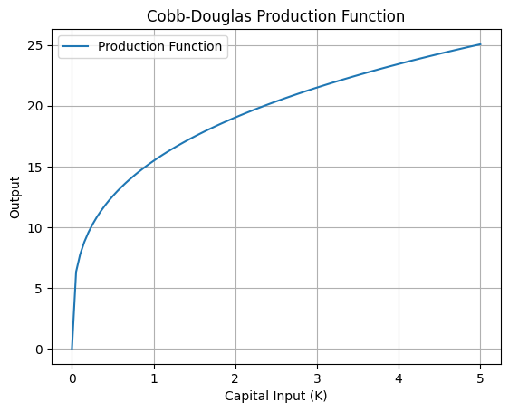

```python
def CobbDouglas(A, K, L, alpha):
    '''
    This function computes the level of output of a Cobb-Douglas production function.
    Given values of K, L, A, and alpha it returns $A\cdot K^\alpha \cdot L^{1-\alpha}$.
    Parameters:
    -----------
    K: float, integer or any other number, default=1
    L: float, integer or any other number, default=1
    A: float, integer or any other number, default=1
    alpha: float between (0,1), default=0.3

    Returns:
    --------
    out = A * K**alpha * L**(1-alpha)

    Example:
    >>> out = CobbDouglas(4, 9, 2, 1/2)
    >>> out
        12
    '''
    output = A * (K ** alpha) * (L ** (1 - alpha))
    return output

# Given values
A = 1.0  # Total factor productivity
L = 50.0  # Labor input
alpha = 0.3  # Capital's share in output

# Generate an array of values for K
K_values = np.linspace(0, 5, 100)

# Compute the output for each value of K
output_values = CobbDouglas(A, K_values, L, alpha)

# Plot the production function
plt.plot(K_values, output_values, label='Production Function')
plt.xlabel('Capital Input (K)')
plt.ylabel('Output')
plt.title('Cobb-Douglas Production Function')
plt.grid(True)
plt.legend()

# Save the plot as PNG, JPEG, and PDF files
plt.savefig('cobb_douglas_plot_1.png')
plt.savefig('cobb_douglas_plot_1.jpeg')
plt.savefig('cobb_douglas_plot_1.pdf')

plt.show()
```

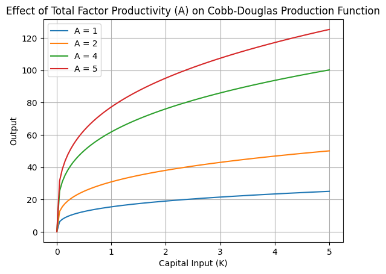

```python
def CobbDouglas(A, K, L, alpha):
    '''
    This function computes the level of output of a Cobb-Douglas production function.
    Given values of K, L, A, and alpha it returns $A\cdot K^\alpha \cdot L^{1-\alpha}$.
    Parameters:
    -----------
    K: float, integer or any other number, default=1
    L: float, integer or any other number, default=1
    A: float, integer or any other number, default=1
    alpha: float between (0,1), default=0.3

    Returns:
    --------
    out = A * K**alpha * L**(1-alpha)

    Example:
    >>> out = CobbDouglas(4, 9, 2, 1/2)
    >>> out
        12
    '''
    output = A * (K ** alpha) * (L ** (1 - alpha))
    return output

# Given values
L = 50.0  # Labor input
alpha = 0.3  # Capital's share in output

# Generate an array of values for K
K_values = np.linspace(0, 5, 100)

# Values of A to analyze
A_values = [1, 2, 4, 5]

# Plot the production function for each value of A
for A in A_values:
    output_values = CobbDouglas(A, K_values, L, alpha)
    plt.plot(K_values, output_values, label=f'A = {A}')

plt.xlabel('Capital Input (K)')
plt.ylabel('Output')
plt.title('Effect of Total Factor Productivity (A) on Cobb-Douglas Production Function')
plt.grid(True)
plt.legend()

# Save the plot as PNG, JPEG, and PDF files
plt.savefig('cobb_douglas_plot_2.png')
plt.savefig('cobb_douglas_plot_2.jpeg')
plt.savefig('cobb_douglas_plot_2.pdf')

plt.show()
```

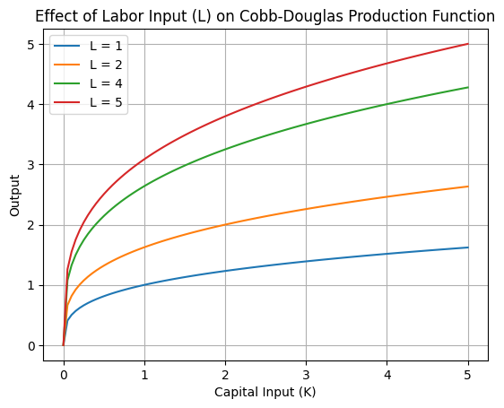

```python
def CobbDouglas(A, K, L, alpha):
    '''
    This function computes the level of output of a Cobb-Douglas production function.
    Given values of K, L, A, and alpha it returns $A\cdot K^\alpha \cdot L^{1-\alpha}$.
    Parameters:
    -----------
    K: float, integer or any other number, default=1
    L: float, integer or any other number, default=1
    A: float, integer or any other number, default=1
    alpha: float between (0,1), default=0.3

    Returns:
    --------
    out = A * K**alpha * L**(1-alpha)

    Example:
    >>> out = CobbDouglas(4, 9, 2, 1/2)
    >>> out
        12
    '''
    output = A * (K ** alpha) * (L ** (1 - alpha))
    return output

# Given values
A = 1.0  # Total factor productivity
alpha = 0.3  # Capital's share in output

# Generate an array of values for K
K_values = np.linspace(0, 5, 100)

# Values of L to analyze
L_values = [1, 2, 4, 5]

# Plot the production function for each value of L
for L in L_values:
    output_values = CobbDouglas(A, K_values, L, alpha)
    plt.plot(K_values, output_values, label=f'L = {L}')

plt.xlabel('Capital Input (K)')
plt.ylabel('Output')
plt.title('Effect of Labor Input (L) on Cobb-Douglas Production Function')
plt.grid(True)
plt.legend()

# Save the plot as PNG, JPEG, and PDF files
plt.savefig('cobb_douglas_plot_3.png')
plt.savefig('cobb_douglas_plot_3.jpeg')
plt.savefig('cobb_douglas_plot_3.pdf')

plt.show()
```

**Exercise 6:** Use the `IFrame` function to show the website from where you are planning to obtain data.

```python
from IPython.display import IFrame

# Replace 'your_iframe_url' with the actual URL of your iframe
iframe_url = 'https://www.worldvaluessurvey.org/wvs.jsp'

# Create an IFrame with specified width and height
iframe = IFrame(iframe_url, width=600, height=400)

# Display the IFrame
iframe
```

[interactive chart not shown]

```python
from IPython.display import IFrame

url = "https://www.worldvaluessurvey.org/wvs.jsp"
IFrame(url, width="100%", height="600px")
```

[interactive chart not shown]

**Exercise 7:** Use the `IFrame` function to insert an iframe showing the graph for the evolution of *patent applications* by residents across the world using the **World Development Indicators** website.

```python
from IPython.display import IFrame

url = "https://ourworldindata.org/grapher/patent-applications-per-million?tab=chart"
IFrame(url, width="100%", height="600px")
```

[interactive chart not shown]

[figure not shown]

Created in Deepnote